# Workfow to create image subsets for field mapping

Sarah Graves

October 19, 2016

## R Markdown

The purpose of this workflow is to have an automated way to create image subsets surrounding NEON plots. The basic process is to read in a spatial points file of all plot locations, identify the correct flight path (either spatially or by reading an attribute in the point file), extract 3-band combinations from the HDF5 files, and save raster files to load onto the iPad.

```r
library(sp)
library(rgdal)
library(raster)
library(neonAOP)
library(rhdf5)

# read in custom function
source("scripts/functions.R")
```

## Load spatial data and identify flight path

This step identifies the path number for a specified plot ID. The fight path was manually added to the spatial polygon shapefile. This was done because often there are two flight paths that intersect a single NEON plot center. Manual assignment of a NEON plot to a flight path ensures that the best flight path is chosen. The primary considerations for which path is optimal are 1) lack of clouds or cloud shadows, and 2) position in the center of the flight path to reduce look angle effects.

```r
find_flight_path
```

```
## function (spatial_file, plot_string, plot_column, path_column)
## {
##     df <- spatial_file@data
##     path <- df[which(df[, plot_column] == plot_string), path_column]
##     return(path)
## }
```

The next step is to find the HDF5 file that corresponds to the identified flight path. Often the files are stored in a single folder for the year and site. Therefore, the function should search through the list of file and find the file with the flight path in the name

```r
create_file_path
```

```
## function (file_folder, path)
## {
##     h5_file <- list.files(file_folder, full.names = T)[grep(path,
##         list.files(file_folder))]
##     return(h5_file)
## }
```

Once the specific file has been identified more complex functions to extract information from the HDF5 files can be used.

```r
find_point_coordinates
```

```
## function (spatial_file, plot_string, plot_column)
## {
##     df <- spatial_file@data
##     r <- which(df[, plot_column] == plot_string)
##     plot_coords <- spatial_file@coords[r, ]
##     return(unname(plot_coords))
## }
```

```r
create_extent_around_point
```

```
## function (point_coordinates, buffer_size)
## {
##     xmin <- round(point_coordinates[1] - buffer_size)
##     xmax <- round(point_coordinates[1] + buffer_size)
##     ymin <- round(point_coordinates[2] - buffer_size)
##     ymax <- round(point_coordinates[2] + buffer_size)
##     point_extent <- extent(xmin, xmax, ymin, ymax)
##     return(point_extent)
## }
```

These functions can be applied sequentially. The full workflow requires use of the neonAOP package by Leah Wasser.

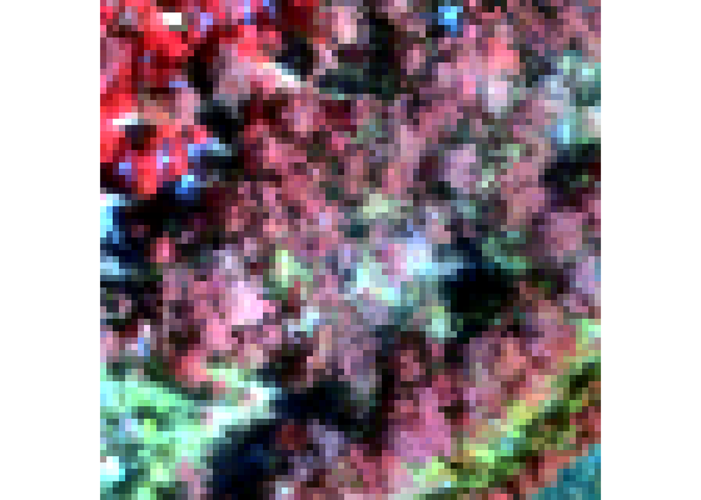

```r
# read in shapefile
p_full <- readOGR("../data/NEON_plot_spatial_data","OSBS_diversity_plot_centroids",verbose = F)

# often data is stored in an external drive, need a pointer to this folder
file_folder <- "G:/NEON_AOP_downloads/OSBS_Reflectance"

plot_name <- "OSBS_020"

img_bands <- c(177,53,16)
name_bands <- paste(img_bands[1],img_bands[2],img_bands[3],sep="-")

img_file_name <- paste(plot_name,name_bands,sep="_")


# 1. identify path
path <- find_flight_path(p_full,plot_name,2,11)

# 2. create path name
h5_file <- create_file_path(file_folder,path)

# 3. extract plot coordinates
plot_coords <- find_point_coordinates(p_full,plot_name,2)

# 4. create extent around point
plot_extent <- create_extent_around_point(plot_coords,40)

# 5. create extent object for H5 file
h5_extent <- create_extent(h5_file)

# create new extent object that can be applied in the create_stack function
extent_to_clip <- calculate_index_extent(clipExtent = plot_extent,
                                         h5Extent = h5_extent)

# 6. Create multi-band raster object
rgbimage <- create_stack(h5_file,
             bands=c(177,53,16),
             epsg = 32617,
             subset=T,
             dims = extent_to_clip)

plotRGB(rgbimage,stretch="lin")
```

```r
# 7. Save raster to file
save_raster_image(rgbimage,file_name = img_file_name, flatten = T)
```